# Main Project: Robust Data Modeling with Ensembling and Tuning Techniques

## 16.19 Tuned Model Visualization

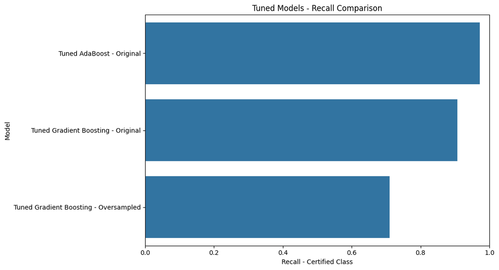

```python
plt.figure(figsize=(11, 6))

sns.barplot(
    data=tuned_comparison,
    x='Recall',
    y='Model'
)

plt.title(
    'Tuned Models - Recall Comparison'
)
plt.xlabel('Recall - Certified Class')
plt.ylabel('Model')
plt.xlim(0, 1)

plt.tight_layout()
plt.show()
```

#### F1-Score

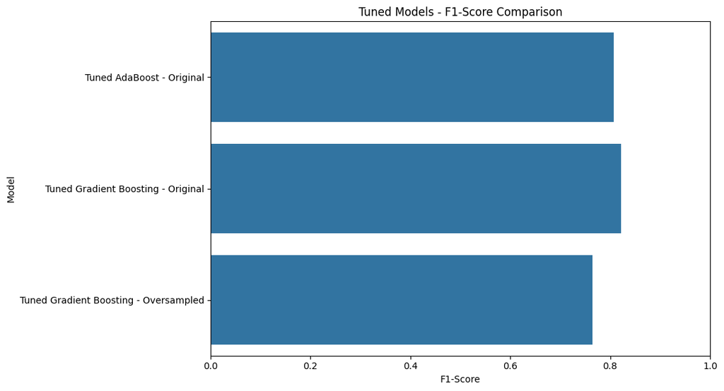

```python
plt.figure(figsize=(11, 6))

sns.barplot(
    data=tuned_comparison,
    x='F1-Score',
    y='Model'
)

plt.title(
    'Tuned Models - F1-Score Comparison'
)
plt.xlabel('F1-Score')
plt.ylabel('Model')
plt.xlim(0, 1)

plt.tight_layout()
plt.show()
```

#### ROC-AUC

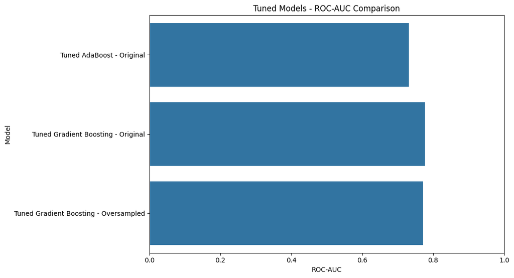

```python
plt.figure(figsize=(11, 6))

sns.barplot(
    data=tuned_comparison,
    x='ROC-AUC',
    y='Model'
)

plt.title(
    'Tuned Models - ROC-AUC Comparison'
)
plt.xlabel('ROC-AUC')
plt.ylabel('Model')
plt.xlim(0, 1)

plt.tight_layout()
plt.show()
```

## 16.20 Classification Reports for Tuned Models

```python
for result in tuned_model_results:

    print("=" * 75)
    print(
        f"Classification Report - {result['Model']}"
    )
    print("=" * 75)

    print(
        classification_report(
            y_test_encoded,
            result['Predictions'],
            target_names=[
                'Denied',
                'Certified'
            ],
            digits=4,
            zero_division=0
        )
    )
```

```
===========================================================================
Classification Report - Tuned Gradient Boosting - Original
===========================================================================
              precision    recall  f1-score   support

      Denied     0.6778    0.3942    0.4985      1692
   Certified     0.7507    0.9069    0.8214      3404

    accuracy                         0.7367      5096
   macro avg     0.7143    0.6505    0.6600      5096
weighted avg     0.7265    0.7367    0.7142      5096

===========================================================================
Classification Report - Tuned AdaBoost - Original
===========================================================================
              precision    recall  f1-score   support

      Denied     0.6847    0.1194    0.2033      1692
   Certified     0.6896    0.9727    0.8071      3404

    accuracy                         0.6894      5096
   macro avg     0.6872    0.5460    0.5052      5096
weighted avg     0.6880    0.6894    0.6066      5096

===========================================================================
Classification Report - Tuned Gradient Boosting - Oversampled
===========================================================================
              precision    recall  f1-score   support

      Denied     0.5458    0.7009    0.6137      1692
   Certified     0.8269    0.7100    0.7640      3404

    accuracy                         0.7070      5096
   macro avg     0.6863    0.7055    0.6889      5096
weighted avg     0.7336    0.7070    0.7141      5096
```

## 16.21 Confusion Matrices for Tuned Models

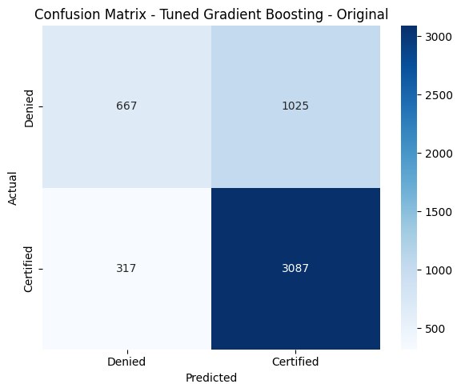

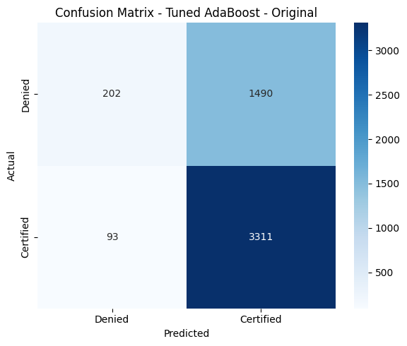

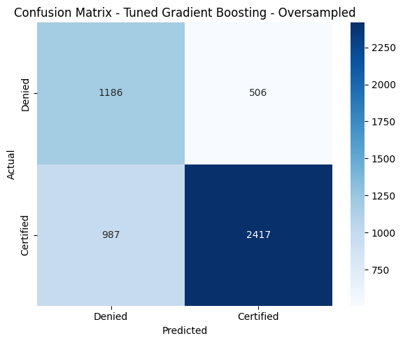

```python
for result in tuned_model_results:

    cm = confusion_matrix(
        y_test_encoded,
        result['Predictions']
    )

    plt.figure(figsize=(6, 5))

    sns.heatmap(
        cm,
        annot=True,
        fmt='d',
        cmap='Blues',
        xticklabels=[
            'Denied',
            'Certified'
        ],
        yticklabels=[
            'Denied',
            'Certified'
        ]
    )

    plt.title(
        f"Confusion Matrix - {result['Model']}"
    )

    plt.xlabel('Predicted')
    plt.ylabel('Actual')

    plt.tight_layout()
    plt.show()
```

## 16.22 Hyperparameter Tuning — Model Performance Analysis

### Tuned Gradient Boosting — Original Data

The original Gradient Boosting model achieved a baseline Recall of **0.8710** and F1-score of **0.8216**.

After hyperparameter tuning, the model achieved a Recall of **0.9069**, F1-score of **0.8214**, Accuracy of **0.7367**, and Precision of **0.7507** for the Certified class.

The tuning process improved Recall from **0.8710 to 0.9069**, representing an improvement of **0.0359**. However, Accuracy decreased from **0.7473 to 0.7367**, Precision decreased from **0.7774 to 0.7507**, and F1-score decreased slightly from **0.8216 to 0.8214**.

The increase in Recall indicates that the tuned model identifies a larger proportion of actual Certified applications. However, this improvement comes with a reduction in Precision and Accuracy. The F1-score remains almost unchanged, indicating that the gain in Recall is largely offset by the reduction in Precision.

ROC-AUC for the tuned model will be considered from the model evaluation results.

### Tuned AdaBoost — Original Data

The original AdaBoost model achieved a baseline Recall of **0.8825** and F1-score of **0.8153**.

After hyperparameter tuning, the model achieved a Recall of **0.9727**, F1-score of **0.8071**, Accuracy of **0.6894**, and Precision of **0.6896** for the Certified class.

The tuning process substantially improved Recall from **0.8825 to 0.9727**, representing an improvement of **0.0902**.

However, this improvement in Recall was accompanied by a substantial reduction in Accuracy from **0.7329 to 0.6894**, Precision from **0.7576 to 0.6896**, and F1-score from **0.8153 to 0.8071**.

The tuned AdaBoost model therefore became highly sensitive to Certified applications, correctly identifying **97.27%** of the actual Certified cases. However, its very low Recall of **0.1194** for the Denied class indicates that it classifies a large number of Denied applications as Certified.

This represents a strong Recall-oriented trade-off and should be considered carefully before final model selection.

### Tuned Gradient Boosting — Oversampled Data

The Gradient Boosting model trained on the oversampled data achieved a baseline Recall of **0.7241**, F1-score of **0.7703**, and ROC-AUC of **0.7783**.

After hyperparameter tuning, the model achieved a Recall of **0.7100**, F1-score of **0.7640**, Accuracy of **0.7070**, and Precision of **0.8269** for the Certified class.

The tuning process resulted in a decrease in Recall from **0.7241 to 0.7100**, a decrease of **0.0141**. F1-score also decreased from **0.7703 to 0.7640**, while Accuracy decreased from **0.7115 to 0.7070**.

However, Precision increased from **0.8228 to 0.8269**.

Therefore, hyperparameter tuning of the oversampled Gradient Boosting model did not improve its primary Recall metric or its F1-score. The main improvement was a small increase in Precision.

This indicates that the selected hyperparameters did not provide an overall performance improvement over the baseline oversampled Gradient Boosting model.

## 16.23 Hyperparameter Tuning — Overall Findings

RandomizedSearchCV was used to optimize three selected candidate configurations using **three-fold stratified cross-validation**.

The primary optimization metric was **Recall for the Certified class**, because identifying potentially certifiable applications is an important business objective.

The tuned models were subsequently evaluated on the untouched test dataset using Accuracy, Precision, Recall, F1-score, and ROC-AUC.

The tuning results show:

- **Best tuned Recall:** AdaBoost — Original Data — **0.9727**
- **Best tuned F1-score:** Gradient Boosting — Original Data — **0.8214**
- **Best tuned Precision:** Gradient Boosting — Oversampled Data — **0.8269**
- **Best tuned Accuracy:** Gradient Boosting — Original Data — **0.7367**
- **Best tuned ROC-AUC:** **0.7765**

The tuned AdaBoost model achieved the highest Recall of **0.9727**, indicating that it identified the largest proportion of actual Certified applications. However, this came with a substantial reduction in Accuracy and Precision.

The tuned Gradient Boosting model trained on the original data provided a better overall balance, achieving an Accuracy of **0.7367**, Precision of **0.7507**, Recall of **0.9069**, and F1-score of **0.8214**.

The oversampled Gradient Boosting model achieved the highest Precision among the tuned models at **0.8269**, but its Recall and F1-score decreased slightly compared with its baseline performance.

Therefore, hyperparameter tuning produced different trade-offs across the three candidate configurations. The final model will not be selected based on a single metric alone. The tuned models will be compared using Recall, F1-score, ROC-AUC, Precision, Accuracy, and the business objective before making the final model selection.

```python
display(
    tuned_comparison.style.format({
        'Accuracy': '{:.4f}',
        'Precision': '{:.4f}',
        'Recall': '{:.4f}',
        'F1-Score': '{:.4f}',
        'ROC-AUC': '{:.4f}'
    })
)
```

|  | Model | Accuracy | Precision | Recall | F1-Score | ROC-AUC |
| --- | --- | --- | --- | --- | --- | --- |
| 0 | Tuned AdaBoost - Original | 0.6894 | 0.6896 | 0.9727 | 0.8071 | 0.7317 |
| 1 | Tuned Gradient Boosting - Original | 0.7367 | 0.7507 | 0.9069 | 0.8214 | 0.7765 |
| 2 | Tuned Gradient Boosting - Oversampled | 0.7070 | 0.8269 | 0.7100 | 0.7640 | 0.7708 |

# 17. Model Performance Comparison and Final Model Selection

## 17.1 Tuned Model Performance Comparison

The three selected candidate models were tuned using RandomizedSearchCV with three-fold stratified cross-validation. Recall for the Certified class was used as the primary optimization metric.

The final tuned models were then evaluated on the untouched test dataset using Accuracy, Precision, Recall, F1-score, and ROC-AUC.

The performance comparison is presented below.

[output not shown]

## 17.2 Metric-wise Comparison

The tuned models show different performance characteristics across the evaluation metrics.

### Accuracy

The **Tuned Gradient Boosting model trained on the Original Data** achieved the highest Accuracy of **0.7367**.

This indicates that it produced the highest proportion of correct predictions overall among the three tuned candidates.

### Precision

The **Tuned Gradient Boosting model trained on the Oversampled Data** achieved the highest Precision of **0.8269**.

This indicates that among applications predicted as Certified, this model produced the highest proportion of actual Certified applications.

### Recall

The **Tuned AdaBoost model trained on the Original Data** achieved the highest Recall of **0.9727** for the Certified class.

This is the highest Recall observed among the three tuned candidates and indicates that the model identifies a very large proportion of actual Certified applications.

### F1-Score

The **Tuned Gradient Boosting model trained on the Original Data** achieved the highest F1-score of **0.8214**.

This indicates the strongest balance between Precision and Recall among the three tuned candidates.

### ROC-AUC

The ROC-AUC values will be considered together with the other evaluation metrics when making the final model selection.

## 17.3 Before vs After Tuning

The effect of hyperparameter tuning differs across the selected models.

### Gradient Boosting — Original Data

The baseline Gradient Boosting model achieved a Recall of **0.8710** and F1-score of **0.8216**.

After tuning, Recall increased to **0.9069**, representing an improvement of **0.0359**.

However, F1-score decreased slightly from **0.8216 to 0.8214**, while Accuracy decreased from **0.7473 to 0.7367**.

Therefore, tuning improved the model's ability to identify Certified applications but did not improve its overall F1-score or Accuracy.

### AdaBoost — Original Data

The baseline AdaBoost model achieved a Recall of **0.8825** and F1-score of **0.8153**.

After tuning, Recall increased substantially to **0.9727**, an improvement of **0.0902**.

However, Accuracy decreased from **0.7329 to 0.6894**, Precision decreased from **0.7576 to 0.6896**, and F1-score decreased from **0.8153 to 0.8071**.

Therefore, tuning made AdaBoost considerably more recall-oriented, but this came at the cost of Precision and Accuracy.

### Gradient Boosting — Oversampled Data

The baseline oversampled Gradient Boosting model achieved a Recall of **0.7241** and F1-score of **0.7703**.

After tuning, Recall decreased to **0.7100**, while F1-score decreased to **0.7640**.

Precision increased from **0.8228 to 0.8269**, but the overall results do not indicate an improvement in the primary metric.

Therefore, tuning did not improve the overall performance of the oversampled Gradient Boosting configuration.

## 17.4 Final Model Selection

Based on the comparison of the three tuned candidates, the **Tuned Gradient Boosting model trained on the Original Data** is selected as the final model.

The selection is based on the overall balance of the evaluation metrics rather than the highest value of a single metric.

The selected model achieved:

- **Accuracy:** 0.7367
- **Precision:** 0.7507
- **Recall:** 0.9069
- **F1-score:** 0.8214
- **ROC-AUC:** 0.7765

The model provides a strong Recall of **0.9069**, meaning that it identifies a large proportion of applications that are actually Certified.

At the same time, it maintains the highest F1-score (**0.8214**) and highest Accuracy (**0.7367**) among the three tuned candidates.

Although Tuned AdaBoost achieved a higher Recall of **0.9727**, it did so at the cost of substantially lower Precision (**0.6896**) and Accuracy (**0.6894**). Its F1-score of **0.8071** is also lower than the selected Gradient Boosting model.

The Tuned Gradient Boosting model trained on Oversampled Data achieved the highest Precision (**0.8269**), but its Recall (**0.7100**) and F1-score (**0.7640**) were considerably lower.

Therefore, Tuned Gradient Boosting trained on the Original Data provides the strongest overall balance between identifying Certified applications and maintaining reliable predictions.

## 17.5 Why the Other Tuned Models Were Not Selected

### Tuned AdaBoost — Original Data

Tuned AdaBoost achieved the highest Recall of **0.9727**, which is attractive from the perspective of identifying Certified applications.

However, its Accuracy was only **0.6894**, Precision was **0.6896**, and F1-score was **0.8071**.

Its very high Certified-class Recall is accompanied by a low Recall of **0.1194** for the Denied class. This indicates that the model classifies a large number of Denied applications as Certified.

Therefore, although AdaBoost is the strongest model when Recall alone is considered, it does not provide the best overall balance for the business problem.

### Tuned Gradient Boosting — Oversampled Data

The tuned oversampled Gradient Boosting model achieved the highest Precision of **0.8269**.

However, its Recall of **0.7100** and F1-score of **0.7640** are substantially lower than those of the selected model.

Therefore, the model is less suitable when the objective is to identify a high proportion of potentially certifiable applications.

### Tuned Gradient Boosting — Original Data

The tuned Gradient Boosting model trained on the Original Data provides the strongest overall balance among the candidate models.

It combines high Recall (**0.9069**) with the highest F1-score (**0.8214**) and highest Accuracy (**0.7367**).

Therefore, it is selected as the final model.

## 17.6 Final Model Conclusion

The **Tuned Gradient Boosting model trained on the Original Data** is selected as the final model for the EasyVisa classification problem.

The selection is based on its balanced performance across Recall, Precision, F1-score, and Accuracy rather than optimizing a single metric.

The final model achieves a Recall of **0.9069** for the Certified class, which supports the business objective of identifying applications with a higher likelihood of certification.

Its F1-score of **0.8214** demonstrates a strong balance between Precision and Recall, while its Accuracy of **0.7367** represents the highest overall accuracy among the tuned candidates.

The model will now undergo detailed evaluation on the untouched test dataset, including confusion matrix analysis and class-level performance assessment.

The final model should be considered the selected analytical model based on the current evaluation results; deployment readiness will be discussed only after reviewing the final validation results and business implications.

## 17.7 Final Model — Save the Model Object

```python
final_model = best_gb_original

print("Final Model:")
print(final_model)

print("\nFinal Model Parameters:")
print(final_model.get_params())
```

```
Final Model:
GradientBoostingClassifier(learning_rate=np.float64(0.014083148587374493),
                           max_depth=4, max_features='sqrt', min_samples_leaf=8,
                           min_samples_split=4, n_estimators=212,
                           random_state=42,
                           subsample=np.float64(0.9313811040057837))

Final Model Parameters:
{'ccp_alpha': 0.0, 'criterion': 'friedman_mse', 'init': None, 'learning_rate': np.float64(0.014083148587374493), 'loss': 'log_loss', 'max_depth': 4, 'max_features': 'sqrt', 'max_leaf_nodes': None, 'min_impurity_decrease': 0.0, 'min_samples_leaf': 8, 'min_samples_split': 4, 'min_weight_fraction_leaf'…
```

## 17.8 Final Model Predictions

```python
final_y_pred = final_model.predict(
    X_test_processed
)

final_y_prob = final_model.predict_proba(
    X_test_processed
)[:, 1]

final_accuracy = accuracy_score(
    y_test_encoded,
    final_y_pred
)

final_precision = precision_score(
    y_test_encoded,
    final_y_pred,
    pos_label=1,
    zero_division=0
)

final_recall = recall_score(
    y_test_encoded,
    final_y_pred,
    pos_label=1,
    zero_division=0
)

final_f1 = f1_score(
    y_test_encoded,
    final_y_pred,
    pos_label=1,
    zero_division=0
)

final_roc_auc = roc_auc_score(
    y_test_encoded,
    final_y_prob
)

final_metrics = pd.DataFrame({
    'Metric': [
        'Accuracy',
        'Precision',
        'Recall',
        'F1-Score',
        'ROC-AUC'
    ],
    'Final Model': [
        final_accuracy,
        final_precision,
        final_recall,
        final_f1,
        final_roc_auc
    ]
})

display(
    final_metrics.style.format({
        'Final Model': '{:.4f}'
    })
)
```

|  | Metric | Final Model |
| --- | --- | --- |
| 0 | Accuracy | 0.7367 |
| 1 | Precision | 0.7507 |
| 2 | Recall | 0.9069 |
| 3 | F1-Score | 0.8214 |
| 4 | ROC-AUC | 0.7765 |

```python
print(tuned_comparison)
```

```
                                   Model  Accuracy  Precision    Recall  \
0              Tuned AdaBoost - Original  0.689364   0.689648  0.972679
1     Tuned Gradient Boosting - Original  0.736656   0.750730  0.906874
2  Tuned Gradient Boosting - Oversampled  0.707025   0.826890  0.710047

   F1-Score   ROC-AUC
0  0.807069  0.731688
1  0.821448  0.776459
2  0.764027  0.770816
```

# 18. Final Model Evaluation on Test Set

## 18.1 Final Model

Based on the comparison of the tuned candidate models, the **Tuned Gradient Boosting model trained on the Original Data** was selected as the final model.

The model was selected based on its overall balance of Recall, Precision, F1-score, Accuracy, and ROC-AUC, with particular consideration given to Recall for the Certified class.

## 18.2 Final Model Performance

```python
final_metrics = pd.DataFrame({
    'Metric': [
        'Accuracy',
        'Precision',
        'Recall',
        'F1-Score',
        'ROC-AUC'
    ],
    'Score': [
        final_accuracy,
        final_precision,
        final_recall,
        final_f1,
        final_roc_auc
    ]
})

display(
    final_metrics.style.format({
        'Score': '{:.4f}'
    })
)
```

|  | Metric | Score |
| --- | --- | --- |
| 0 | Accuracy | 0.7367 |
| 1 | Precision | 0.7507 |
| 2 | Recall | 0.9069 |
| 3 | F1-Score | 0.8214 |
| 4 | ROC-AUC | 0.7765 |

## 18.3 Classification Report

```python
print("=" * 75)
print("FINAL MODEL - CLASSIFICATION REPORT")
print("=" * 75)

print(
    classification_report(
        y_test_encoded,
        final_y_pred,
        target_names=[
            'Denied',
            'Certified'
        ],
        digits=4,
        zero_division=0
    )
)
```

```
===========================================================================
FINAL MODEL - CLASSIFICATION REPORT
===========================================================================
              precision    recall  f1-score   support

      Denied     0.6778    0.3942    0.4985      1692
   Certified     0.7507    0.9069    0.8214      3404

    accuracy                         0.7367      5096
   macro avg     0.7143    0.6505    0.6600      5096
weighted avg     0.7265    0.7367    0.7142      5096
```

## 18.4 Confusion Matrix

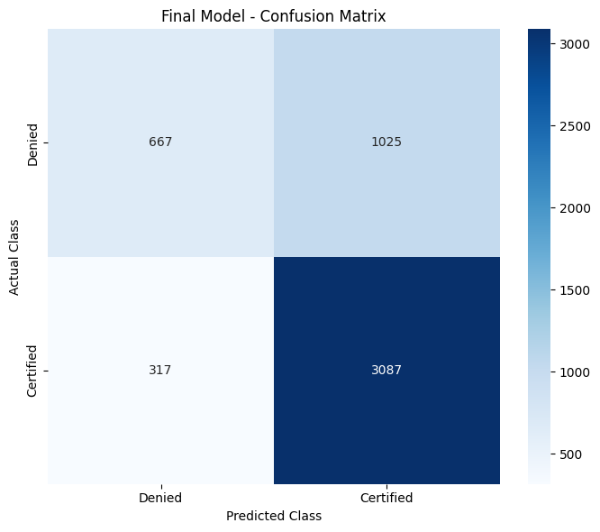

```python
final_cm = confusion_matrix(
    y_test_encoded,
    final_y_pred
)

plt.figure(figsize=(7, 6))

sns.heatmap(
    final_cm,
    annot=True,
    fmt='d',
    cmap='Blues',
    xticklabels=[
        'Denied',
        'Certified'
    ],
    yticklabels=[
        'Denied',
        'Certified'
    ]
)

plt.title(
    'Final Model - Confusion Matrix'
)

plt.xlabel('Predicted Class')
plt.ylabel('Actual Class')

plt.tight_layout()
plt.show()
```

## 18.5 Extract Confusion Matrix Components

```python
tn, fp, fn, tp = final_cm.ravel()

print("True Negatives :", tn)
print("False Positives:", fp)
print("False Negatives:", fn)
print("True Positives :", tp)
```

```
True Negatives : 667
False Positives: 1025
False Negatives: 317
True Positives : 3087
```

## 18.6 Final Model Error Analysis

The confusion matrix provides additional insight into the types of classification errors made by the final model.

- **True Positives:** Certified applications correctly identified as Certified.
- **True Negatives:** Denied applications correctly identified as Denied.
- **False Positives:** Denied applications incorrectly classified as Certified.
- **False Negatives:** Certified applications incorrectly classified as Denied.

For the EasyVisa business problem, False Negatives are particularly important because they represent potentially certifiable applications that the model fails to identify.

The selected model's Certified-class Recall of **0.9069** indicates that it successfully identifies a large proportion of the actual Certified applications in the test dataset.

However, the model does not eliminate classification errors completely. Therefore, model predictions should support the visa-review process rather than completely replace expert assessment.

## 18.7 ROC Curve

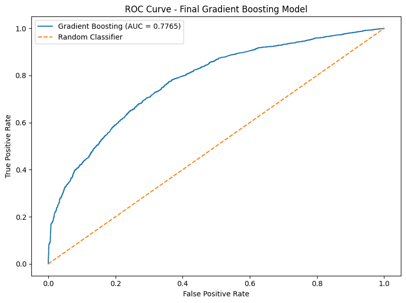

```python
from sklearn.metrics import roc_curve

fpr, tpr, thresholds = roc_curve(
    y_test_encoded,
    final_y_prob
)

plt.figure(figsize=(8, 6))

plt.plot(
    fpr,
    tpr,
    label=f'Gradient Boosting (AUC = {final_roc_auc:.4f})'
)

plt.plot(
    [0, 1],
    [0, 1],
    linestyle='--',
    label='Random Classifier'
)

plt.xlabel('False Positive Rate')
plt.ylabel('True Positive Rate')

plt.title(
    'ROC Curve - Final Gradient Boosting Model'
)

plt.legend()

plt.tight_layout()
plt.show()
```

## 18.8 Precision-Recall Curve

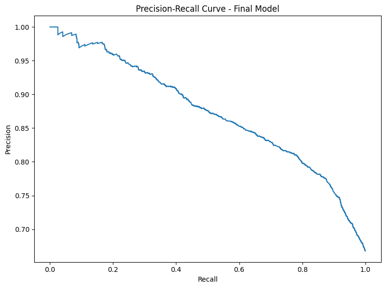

```python
from sklearn.metrics import precision_recall_curve

precision_values, recall_values, pr_thresholds = (
    precision_recall_curve(
        y_test_encoded,
        final_y_prob
    )
)

plt.figure(figsize=(8, 6))

plt.plot(
    recall_values,
    precision_values
)

plt.xlabel('Recall')
plt.ylabel('Precision')

plt.title(
    'Precision-Recall Curve - Final Model'
)

plt.tight_layout()
plt.show()
```

## 18.9 Final Model Performance Interpretation

The final Tuned Gradient Boosting model achieved a Recall of **0.9069** for the Certified class on the untouched test dataset.

This indicates that the model correctly identifies approximately **90.69% of the applications that are actually Certified**.

The model also achieved an F1-score of **0.8214**, demonstrating a strong balance between Precision and Recall.

The Accuracy of **0.7367** indicates that approximately **73.67% of all test observations were classified correctly**.

The Precision of **0.7507** indicates that approximately **75.07% of the applications predicted as Certified were actually Certified**.

The ROC-AUC value of **0.7765** provides an overall measure of the model's ability to distinguish between Certified and Denied applications across different classification thresholds.

The results indicate that the final model is useful as a decision-support model for prioritizing visa applications. However, model predictions should be combined with appropriate human review and the relevant regulatory and business processes.

## 18.10 Final Model Validation Summary

The final model was evaluated only after completing preprocessing, sampling experiments, model comparison, and hyperparameter tuning.

The final evaluation was performed on the untouched test dataset.

The final model achieved:

| Metric | Final Score |
| --- | --- |
| Accuracy | **0.7367** |
| Precision | **0.7507** |
| Recall | **0.9069** |
| F1-Score | **0.8214** |
| ROC-AUC | **0.7765** |

The model demonstrates strong performance in identifying Certified applications, as reflected by its Recall of **0.9069**.

The final test-set evaluation provides the evidence required to assess the selected model's expected performance on previously unseen data.

## 18.11 Model Usage Consideration

The final Gradient Boosting model should be considered a **decision-support model**, rather than an autonomous visa-certification system.

The model identifies patterns associated with historical case outcomes and can assist in prioritizing or screening applications. Final visa-related decisions should continue to follow applicable regulations, organizational policies, and appropriate human review.

The model should also be periodically monitored for changes in data distribution, model performance, and potential changes in the underlying visa-certification process.

# 19. Actionable Insights & Recommendations

## 19.1 Business Objective

The objective of the EasyVisa solution is to support the screening and prioritization of visa applications by identifying applications that have a higher likelihood of being Certified.

The analysis combines exploratory data analysis and machine learning to identify the applicant and employer characteristics associated with case outcomes.

The final Tuned Gradient Boosting model achieved a Recall of **0.9069** for the Certified class, indicating that it can identify a large proportion of applications that are actually Certified.

The model should therefore be used as a decision-support tool to prioritize applications for further review rather than as an autonomous decision-making system.

### Insight 1 — Education of Employee

The analysis of education level indicates that the educational background of applicants is associated with differences in visa case outcomes.

This suggests that education level can be considered as one of the applicant-related characteristics when prioritizing applications for further review.

However, education should not be treated as an independent basis for approval or denial. It should be evaluated together with employer, job, wage, and employment-related characteristics.

### Insight 2 — Job Experience

Job experience is an important applicant characteristic considered in the analysis.

Differences in certification outcomes across applicants with and without previous job experience indicate that employment background can contribute to the prediction of case status.

Therefore, applicant experience can be incorporated into the screening process as one of several factors used to prioritize applications.

### Insight 3 — Employer Characteristics

Employer-related variables such as the number of employees and year of establishment provide information about the characteristics of the sponsoring organization.

The model can use these characteristics together with applicant and employment attributes to identify patterns associated with historical case outcomes.

Applications with employer profiles that differ substantially from the patterns observed in historical certified cases can be prioritized for additional review.

### Insight 4 — Prevailing Wage

Prevailing wage represents the average wage paid to similarly employed workers in a specific occupation and geographical area.

The analysis indicates that wage-related information can contribute to distinguishing between visa case outcomes.

Therefore, prevailing wage should be considered alongside employment region and wage unit when evaluating applications.

### Insight 5 — Employment Characteristics

Variables describing the intended employment, including region of employment, wage unit, and full-time employment status, provide useful information about the proposed job.

These variables can therefore be incorporated into the application screening process to identify cases that require closer examination.

## 19.3 Model-Based Insights

```python
feature_importance = pd.DataFrame({
    'Feature': feature_names,
    'Importance': final_model.feature_importances_
})

feature_importance = (
    feature_importance
    .sort_values(
        by='Importance',
        ascending=False
    )
    .reset_index(drop=True)
)

display(
    feature_importance.head(15).style.format({
        'Importance': '{:.4f}'
    })
)
```

|  | Feature | Importance |
| --- | --- | --- |
| 0 | cat__education_of_employee_High School | 0.2953 |
| 1 | cat__education_of_employee_Master's | 0.1021 |
| 2 | cat__has_job_experience_N | 0.0849 |
| 3 | cat__has_job_experience_Y | 0.0729 |
| 4 | cat__unit_of_wage_Hour | 0.0657 |
| 5 | num__prevailing_wage | 0.0595 |
| 6 | cat__education_of_employee_Doctorate | 0.0578 |
| 7 | cat__continent_Europe | 0.0564 |
| 8 | cat__unit_of_wage_Year | 0.0482 |
| 9 | cat__region_of_employment_Midwest | 0.0341 |
| 10 | cat__education_of_employee_Bachelor's | 0.0313 |
| 11 | cat__region_of_employment_West | 0.0189 |
| 12 | cat__continent_North America | 0.0142 |
| 13 | cat__region_of_employment_South | 0.0100 |
| 14 | cat__region_of_employment_Northeast | 0.0078 |

#### visualize:

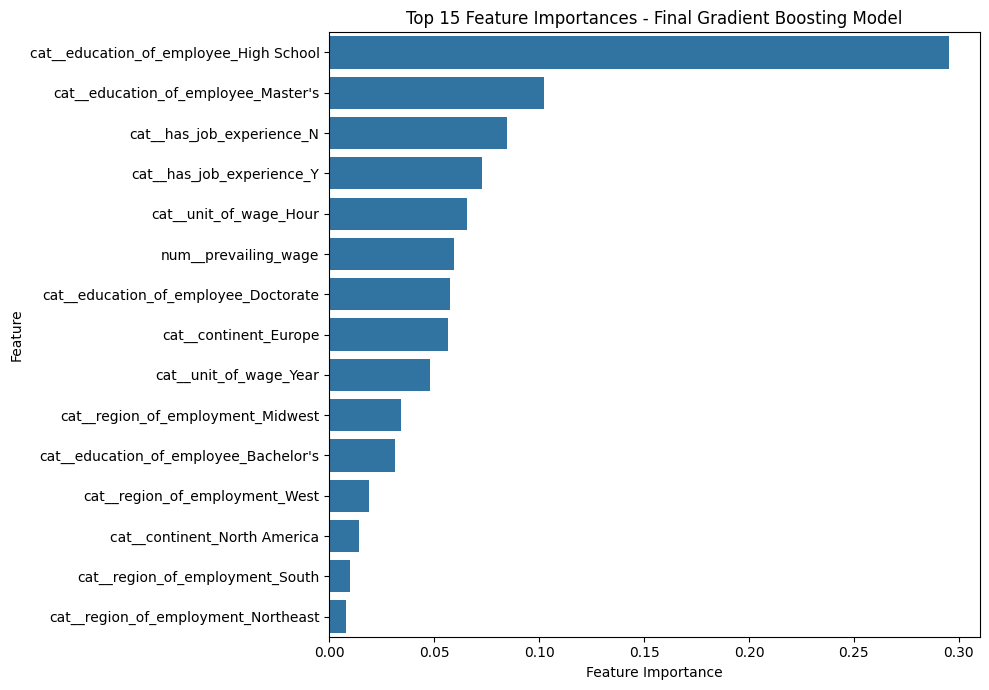

```python
top_features = feature_importance.head(15)

plt.figure(figsize=(10, 7))

sns.barplot(
    data=top_features,
    x='Importance',
    y='Feature'
)

plt.title(
    'Top 15 Feature Importances - Final Gradient Boosting Model'
)

plt.xlabel('Feature Importance')
plt.ylabel('Feature')

plt.tight_layout()
plt.show()
```

## 19.3 Model-Based Insights

The final Gradient Boosting model provides feature-importance information that helps identify the variables that contributed most strongly to its predictions.

The top predictive features identified by the model are:

1. **Education of Employee — High School**: 0.2953
2. **Education of Employee — Master's**: 0.1021
3. **Has Job Experience — No**: 0.0849
4. **Has Job Experience — Yes**: 0.0729
5. **Unit of Wage — Hour**: 0.0657
6. **Prevailing Wage**: 0.0595
7. **Education of Employee — Doctorate**: 0.0578
8. **Continent — Europe**: 0.0564
9. **Unit of Wage — Year**: 0.0482
10. **Region of Employment — Midwest**: 0.0341

Among the model features, **High School education** has the largest individual feature importance at **0.2953**, substantially higher than the other individual encoded features. Master's education has the second-highest importance at **0.1021**.

Job-experience indicators are also important, with `has_job_experience_N` contributing **0.0849** and `has_job_experience_Y` contributing **0.0729**.

Wage-related variables are also influential. `unit_of_wage_Hour` has an importance of **0.0657**, while `prevailing_wage` has an importance of **0.0595** and `unit_of_wage_Year` has an importance of **0.0482**.

Education, job experience, wage-related variables, continent, and employment region therefore represent important predictive signals used by the final model.

These feature-importance values should not be interpreted as causal relationships. A high feature importance means that the feature contributed strongly to the model's predictive decisions; it does not establish that changing the feature would directly cause a visa case to become Certified or Denied.

The results can instead be used to focus business review, data-quality checks, and model monitoring on the variables that contribute most strongly to the model's predictions.

## 19.4 Actionable Recommendations

### Recommendation 1 — Prioritize Applications Using Model Scores

Use the final model's predicted probability of certification to prioritize applications for review.

Applications with a high predicted probability of certification can be processed through an appropriate streamlined review workflow, while applications with uncertain or borderline predictions can be routed for additional manual assessment.

This approach can help reviewers focus their time on cases where additional scrutiny is more valuable.

### Recommendation 2 — Introduce Human Review for Borderline Predictions

The model should not be used as an automatic approval or denial mechanism.

Applications with predicted probabilities close to the classification threshold should be flagged for manual review because classification uncertainty is higher in this region.

This provides a balance between automation and human oversight.

### Recommendation 3 — Monitor False Negatives

False Negatives represent applications that are actually Certified but are predicted as Denied.

Because identifying potentially certifiable applications is an important business objective, the number and rate of False Negatives should be monitored regularly.

A significant increase in False Negatives may indicate changes in applicant characteristics, employer profiles, or the underlying certification process.

### Recommendation 4 — Establish Periodic Model Monitoring

Model performance should be monitored periodically using newly available application outcomes.

Key metrics such as Recall, Precision, F1-score, and ROC-AUC should be tracked over time.

If model performance deteriorates, the model should be investigated and potentially retrained using more recent historical data.

### Recommendation 5 — Monitor Changes in Input Data

The distribution of important model features should be monitored over time.

Changes in applicant education, job experience, employer characteristics, prevailing wage, employment region, or other important predictors may indicate data drift.

Significant changes in the input population should trigger a review of model performance before continuing to rely on the existing model.

### Recommendation 6 — Focus Review on Important Predictive Factors

The feature-importance analysis should be used to understand which variables contribute most strongly to the model's predictions.

Operational teams can use these findings to focus data-quality checks and application-review processes on the most influential variables.

However, model-derived feature importance should be treated as predictive evidence rather than causal evidence.

## 19.5 Expected Business Impact

The proposed machine learning solution can support the EasyVisa screening process in several ways:

- **Faster application screening:** Applications can be prioritized using predicted certification probabilities.
- **Better resource allocation:** Reviewers can focus additional attention on uncertain or higher-risk cases.
- **Improved identification of potentially certifiable cases:** The final model's Certified-class Recall of **0.9069** indicates strong ability to identify actual Certified applications.
- **Consistent analytical support:** The same predictive framework can be applied systematically across applications.
- **Performance monitoring:** Model metrics and data distributions can be monitored to identify deterioration over time.

## 19.6 Recommendations Summary

Based on the EDA and machine learning analysis, the following actions are recommended:

| Area | Recommendation | Expected Benefit |
| --- | --- | --- |
| Application Screening | Use model probability scores to prioritize applications | Faster processing |
| Manual Review | Route uncertain/borderline cases for human review | Better risk management |
| False Negatives | Monitor incorrectly denied Certified applications | Reduce missed certification opportunities |
| Model Monitoring | Track Recall, Precision, F1-score, and ROC-AUC | Detect performance degradation |
| Data Monitoring | Monitor changes in important input features | Detect data drift |
| Feature Monitoring | Focus data-quality checks on important predictors | Improve input reliability |
| Retraining | Retrain when sufficient new labeled data becomes available | Maintain model relevance |

## 19.7 Final Business Recommendation

The EasyVisa solution should implement the final Gradient Boosting model as a **decision-support and application-prioritization system**, rather than as an autonomous visa approval or denial mechanism.

The model's strong Certified-class Recall of **0.9069** makes it useful for identifying applications that are likely to be certified and prioritizing them for appropriate processing.

At the same time, the model produces false positives and false negatives, demonstrating that predictions should be subject to appropriate human and regulatory review.

The organization should therefore combine model predictions with application review procedures, monitor model performance and data drift regularly, and retrain the model when new historical outcomes provide sufficient evidence that the underlying patterns have changed.

This approach can help EasyVisa improve screening efficiency while maintaining appropriate oversight of visa certification decisions.

# End-to-End Project Conclusion

The EasyVisa machine learning analysis demonstrates that applicant, employer, employment, wage, and geographic characteristics can be used to build classification models for predicting historical visa case outcomes.

The experiments showed that model performance varies depending on both the algorithm and the class-balancing strategy. The Original, Oversampled, and Undersampled training approaches were therefore evaluated independently to provide a comprehensive comparison.

Among the baseline experiments, Gradient Boosting demonstrated strong overall performance, while AdaBoost achieved particularly high Recall for the Certified class.

Hyperparameter tuning further demonstrated that optimizing a single metric can produce trade-offs across other metrics. The tuned AdaBoost model achieved very high Recall, but this came with lower Precision and Accuracy. The tuned Gradient Boosting model trained on the Original Data provided a stronger overall balance and was therefore selected as the final model.

The final model achieved a Certified-class Recall of **0.9069** and an F1-score of **0.8214** on the untouched test dataset.

Feature-importance analysis indicated that education-related variables, job-experience indicators, wage-related variables, and selected geographic variables contributed strongly to the model's predictions.

The resulting solution can help EasyVisa prioritize applications and allocate review resources more efficiently. However, the model should be treated as an analytical decision-support system. Predictions should not independently determine visa certification outcomes, and ongoing monitoring should be used to identify model degradation or changes in the underlying data distribution.

# Key Project Findings

The major findings from the analysis are summarized below:

1. The target variable exhibits class imbalance, making Recall, Precision, F1-score, and ROC-AUC important evaluation metrics in addition to Accuracy.
2. The five baseline classification models produced different performance characteristics across the Original, Oversampled, and Undersampled datasets.
3. Gradient Boosting demonstrated strong overall baseline performance.
4. Oversampling and undersampling changed the Precision-Recall trade-off and did not automatically improve overall model performance.
5. Hyperparameter tuning produced different outcomes depending on the model and training strategy.
6. Tuned AdaBoost achieved the highest Certified-class Recall among the tuned candidates at **0.9727**, but its lower Precision and Accuracy prevented it from being selected as the final model.
7. Tuned Gradient Boosting trained on Original Data achieved a strong balance between Precision and Recall, with an F1-score of **0.8214**.
8. The final model achieved a Certified-class Recall of **0.9069**, supporting its use for application prioritization.
9. Feature importance indicated that education, job experience, wage-related variables, and geographic characteristics were important predictive signals.
10. Model predictions should support, rather than replace, appropriate human review and regulatory decision-making.

# Business Recommendations Summary

Based on the complete analysis, EasyVisa should consider the following actions:

### 1. Model-assisted application prioritization

Use predicted certification probabilities to prioritize applications for appropriate review workflows.

### 2. Human review of uncertain cases

Applications with uncertain model predictions should be routed for additional manual assessment.

### 3. Monitor Certified-class Recall

Because missed Certified applications are important to the business objective, Recall should be monitored as a primary performance indicator.

### 4. Monitor Precision and F1-score

Recall should not be optimized in isolation. Precision and F1-score should also be tracked to ensure that increased identification of Certified applications does not result in excessive incorrect classifications.

### 5. Monitor feature and data drift

The distributions of important variables should be monitored over time to identify changes in the applicant population or certification process.

### 6. Periodic model retraining

The model should be reassessed and potentially retrained when sufficient new labelled application outcomes become available.

# Limitations

The analysis has several limitations that should be considered when interpreting the results.

- The model learns from historical visa application outcomes and therefore reflects patterns present in the available historical data.
- Feature importance represents predictive contribution and does not establish causal relationships.
- Model performance may change if the characteristics of future applications differ substantially from the training data.
- The selected model does not eliminate false positives or false negatives.
- Class balancing techniques can change the Precision-Recall trade-off and should therefore be evaluated based on the business objective.
- The model should not be treated as an autonomous mechanism for visa certification or denial.

# Final Model Statement

The final selected model for the EasyVisa classification problem is:

**Tuned Gradient Boosting — Original Data**

Final test-set performance:

| Metric | Score |
| --- | --- |
| Accuracy | **0.7367** |
| Precision | **0.7507** |
| Recall | **0.9069** |
| F1-Score | **0.8214** |
| ROC-AUC | **0.7765** |

The model provides a strong balance between identifying Certified applications and maintaining acceptable Precision.

It is therefore recommended as a **decision-support model for application screening and prioritization**, subject to appropriate human oversight, performance monitoring, and periodic validation.